# 7Shifts Data Analysis

## Objective

Find 1-3 interesting things you find about the conversion rates or other trends in the data. Data provided consists of two files: companies and trials.

## Approach

- Load packages needed
- Load data (companies and trials)
- Get summary statistics for data
- Perform data cleaning if needed
- Find any trends or insights and add write-up as needed

## Load packages

```r
packages <- c('ggplot2', 'corrplot','tidyverse','scales','dplyr', 'lubridate','gridExtra','grid')
for (package in packages) {
  if (!require(package, character.only=T, quietly=T)) {
    install.packages(package)
    library(package, character.only=T)
  }
}
```

## Load data

```r
trials <- read_csv("trials.csv")
companies <- read_csv("companies.csv")
```

## Review data

```r
## Summary and preview company information
summary(companies)
```

```
##        X1          company_id      signup_date         cancellation_date
##  Min.   :  0.0   Min.   : 101.0   Min.   :1920-03-02   Min.   :2019-07-05
##  1st Qu.:249.8   1st Qu.: 350.8   1st Qu.:2020-01-16   1st Qu.:2020-01-22
##  Median :499.5   Median : 600.5   Median :2020-08-24   Median :2020-07-04
##  Mean   :499.5   Mean   : 600.5   Mean   :2020-04-16   Mean   :2020-07-05
##  3rd Qu.:749.2   3rd Qu.: 850.2   3rd Qu.:2021-02-18   3rd Qu.:2020-12-24
##  Max.   :999.0   Max.   :1100.0   Max.   :2021-09-06   Max.   :2021-06-20
##                                                        NA's   :702
##      name
##  Length:1000
##  Class :character
##  Mode  :character
##
##
##
##
```

```r
glimpse(companies)
```

```
## Rows: 1,000
## Columns: 5
## $ X1                <dbl> 0, 1, 2, 3, 4, 5, 6, 7, 8, 9, 10, 11, 12, 13, 14, 15…
## $ company_id        <dbl> 101, 102, 103, 104, 105, 106, 107, 108, 109, 110, 11…
## $ signup_date       <date> 2017-03-18, 2017-06-21, 2017-09-26, 2017-11-05, 201…
## $ cancellation_date <date> 2019-10-29, 2019-09-01, 2019-11-23, 2020-07-08, 202…
## $ name              <chr> "Miller-Alvarez", "Bishop-Chapman", "Schmidt, Shah a…
```

```r
## Summary and preview trial information
summary(trials)
```

```
##        X1         trial_date         customer_name          utm
##  Min.   :   0   Min.   :1920-02-24   Length:10000       Length:10000
##  1st Qu.:2500   1st Qu.:2018-10-19   Class :character   Class :character
##  Median :5000   Median :2019-10-24   Mode  :character   Mode  :character
##  Mean   :5000   Mean   :2019-09-23
##  3rd Qu.:7499   3rd Qu.:2020-09-16
##  Max.   :9999   Max.   :2021-08-30
##
##  display_price     company_id
##  Min.   : 9.00   Min.   : 101.0
##  1st Qu.:19.00   1st Qu.: 350.8
##  Median :29.00   Median : 600.5
##  Mean   :29.27   Mean   : 600.5
##  3rd Qu.:40.00   3rd Qu.: 850.2
##  Max.   :49.00   Max.   :1100.0
##                  NA's   :9000
```

```r
glimpse(trials)
```

```
## Rows: 10,000
## Columns: 6
## $ X1            <dbl> 0, 1, 2, 3, 4, 5, 6, 7, 8, 9, 10, 11, 12, 13, 14, 15, 16…
## $ trial_date    <date> 1920-02-24, 1921-01-04, 2017-03-11, 2017-06-14, 2017-09…
## $ customer_name <chr> "William Anthony", "Mark Wood", "Mary Hampton", "Robin W…
## $ utm           <chr> "organic", "organic", "google", "organic", "organic", "l…
## $ display_price <dbl> 21, 43, 13, 39, 12, 44, 45, 31, 47, 42, 47, 20, 32, 47, …
## $ company_id    <dbl> 396, 790, 101, 102, 103, NA, NA, NA, NA, NA, NA, NA, NA,…
```

```r
## Drop first columns
trials[1] <- NULL
companies[1] <- NULL
```

## Business information

- Conversion rate is defined as the proportion of prospective customers (trials) that made a purchase and became actual customers (companies) within a given time period.
- Trials can be joined to companies via company_id. A trial with no company ID did not convert.

```r
# Combine trials and companies
trials_company <- trials %>%
  inner_join(companies,by = "company_id")
```

```r
## Create trial year
trials_company$trial_year <- lubridate::year(trials_company$trial_date)
## Unique years
unique(trials_company$trial_year)
```

```
## [1] 1920 1921 2017 2018 2019 2020 2021
```

```r
#filter for years on or after 2017 since there are some odd dates
trials_company <- trials_company %>%
  filter(trial_year >= 2017)
```

## Trends

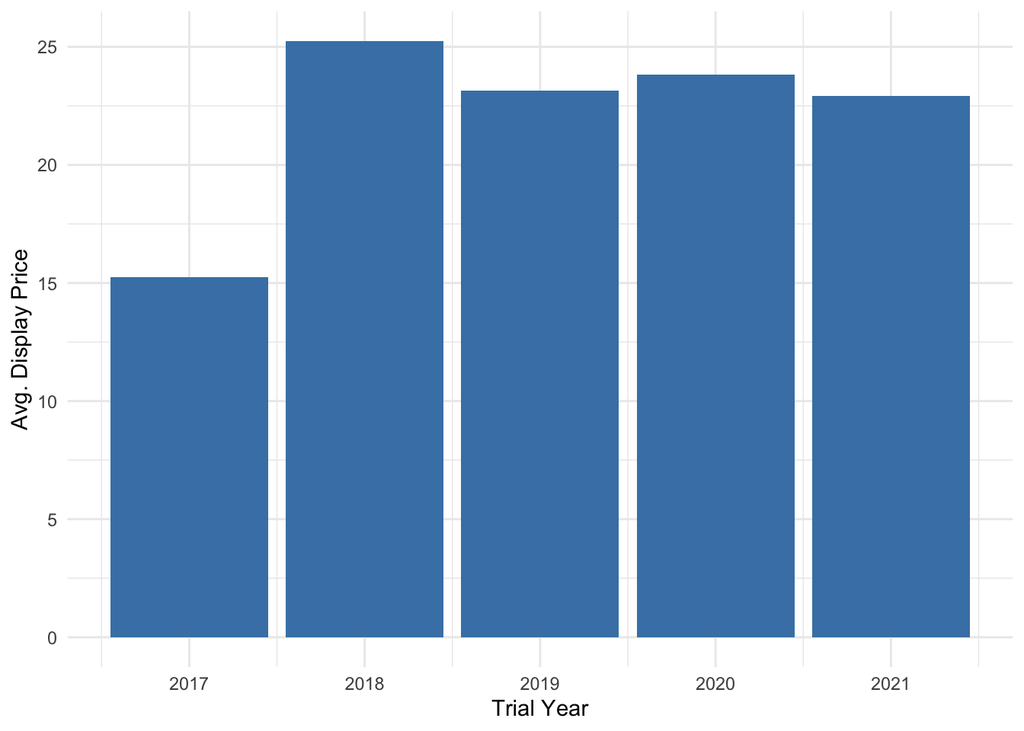

```r
#trial year vs avg display price
trial_avg_display_price <- trials_company %>%
  dplyr::group_by(trial_year) %>%
  dplyr::summarise(avg_display_price = mean(display_price)) %>%
  dplyr::select(trial_year, avg_display_price)


ggplot(data=trial_avg_display_price, aes(x=(trial_year), y=avg_display_price)) +
  geom_bar(stat="identity", fill="steelblue")+
  theme_minimal()+
  xlab("Trial Year") +
  ylab("Avg. Display Price")
```

- Looks like the average display price had a significant increase after 2017.

```r
#trial year vs utm vs avg display price
trial_utm_avg_display_price <- trials_company %>%
  dplyr::group_by(trial_year, utm) %>%
  dplyr::summarise(avg_display_price = mean(display_price)) %>%
  dplyr::select(trial_year, utm, avg_display_price)
```

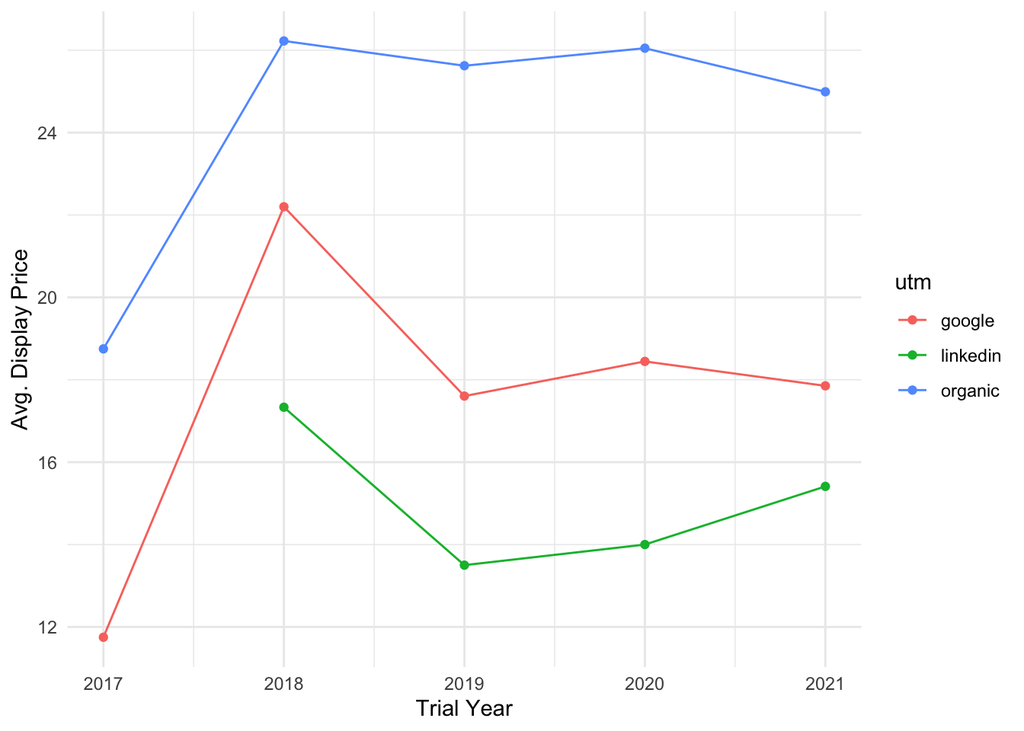

```r
ggplot(trial_utm_avg_display_price, aes(x=(trial_year), y=avg_display_price, group = utm)) +
  geom_line(aes(color=utm)) +
  geom_point(aes(color=utm)) +
  theme_minimal()+
  xlab("Trial Year") +
  ylab("Avg. Display Price")
```

- Organic average display price has been the highest price across all years.
- Google’s average display price took a drop from 2018 and 2019 and has remained steady since.
- Linkedin’s average display price also took a drop from 2018 to 2019 and has been steadily rising since.

```r
#differences between companies that have cancelled vs not cancelled
trial_utm_avg_display_price_other <- trials_company %>%
  dplyr::filter(is.na(cancellation_date)) %>%
  dplyr::group_by(trial_year, utm) %>%
  dplyr::summarise(avg_display_price = mean(display_price)) %>%
  dplyr::select(trial_year, utm, avg_display_price)
```

[figure not shown]

```r
plot1 <- ggplot(trial_utm_avg_display_price_other, aes(x=(trial_year), y=avg_display_price, group = utm)) +
  geom_line(aes(color=utm)) +
  geom_point(aes(color=utm)) +
  theme_minimal()+
  ggtitle("Cancelled ")+
  xlab("Trial Year") +
  ylab("Avg. Display Price")


trial_utm_avg_display_price_other1 <- trials_company %>%
  dplyr::filter(!is.na(cancellation_date)) %>%
  dplyr::group_by(trial_year, utm) %>%
  dplyr::summarise(avg_display_price = mean(display_price)) %>%
  dplyr::select(trial_year, utm, avg_display_price)
plot2 <- ggplot(trial_utm_avg_display_price_other1, aes(x=(trial_year), y=avg_display_price, group = utm)) +
  geom_line(aes(color=utm)) +
  geom_point(aes(color=utm)) +
  #geom_bar(stat="identity",position = "dodge")+
  theme_minimal()+
  ggtitle("Still active")+
  xlab("Trial Year") +
  ylab("Avg. Display Price")


grid.arrange(plot1, plot2, ncol=2)
```